# Acoustic analysis with soundgen

# 5 Audio segmentation with segment()

In addition to measuring spectral characteristics and fundamental frequency, it is often important to analyze the temporal structure of a sound. In particular, it is often helpful to divide a sound into separate “syllables” - continuous acoustic fragments separated by what we consider to be “silence”. If this “silence” was not full of background noise and breathing, the task would be trivial: we could simply define syllables as continuous segments with ampiltude above some threshold. As it is, with non-studio material it is problematic to find a single threshold that would accurately coincide with the beginning and end of syllables in different sounds (presuming that we are interested in batch processing multiple sounds without manually adjusting the settings for each sound). Soundgen attempts to solve this problem by using an adaptive algorithm sensitive to the nature of background noise, signal-to-noise ratio, and acoustic novelty to achieve flexible and fast syllable segmentation.

Sometimes we are more interested in the rate of syllables per second and in their regularity, rather than the absolute duration of each syllable. In this case it makes more sense to look for bursts of acoustic energy or sudden changes relative to background noise. The spacing between bursts - the interburst interval - is a perceptually salient characteristic of a bout of vocalizing.

```
## propNoise set to 0.394; reset manually if needed
```

```
## SNR set to 2.5; reset manually if needed
```

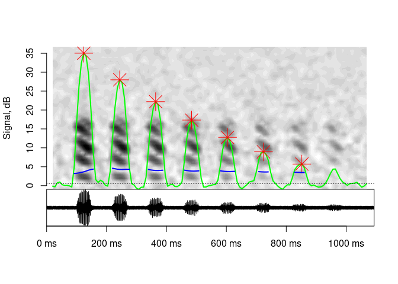

```r
# for info on using soundgen() function, see the vignette on sound synthesis
s2 = soundgen(nSyl = 8, sylLen = 50, pauseLen = 70, temperature = 0,
              pitch = c(368, 284), amplGlobal = c(0, -20))
# add noise so SNR decreases from 20 to 0 dB from syl1 to syl8
s2 = s2 + runif(length(s2), -10 ^ (-20 / 20), 10 ^ (-20 / 20))
# playme(s2, samplingRate = 16000)
a = segment(s2, samplingRate = 16000, plot = TRUE)
```

Some other settings worth mentioning are:

- `propNoise`, `SNR`: two key settings that enable the algorithm to separate signal from noise. If you know how much of your recording(s) is likely to be noise, specify “propNoise”, then use “SNR” to fine-tune the balance between false negatives (missing faint signals) and false positives (hallucinating signals that are actually noise).

```r
a1 = segment(s2, samplingRate = 16000, plot = TRUE,
             SNR = 0.1, main = 'SNR very low')
```

```
## propNoise set to 0.394; reset manually if needed
```

```
## propNoise set to 0.394; reset manually if needed
```

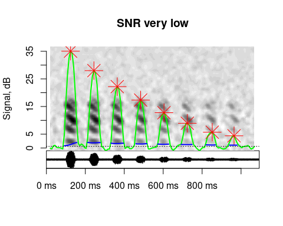

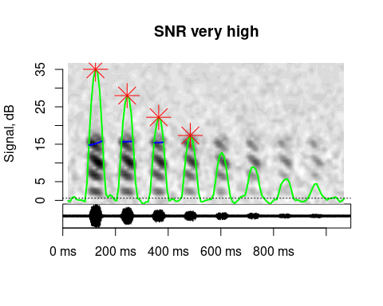

```r
a2 = suppressWarnings(segment(s2, samplingRate = 16000, plot = TRUE,
            SNR = 14, main = 'SNR very high'))
```

- `windowLength`, `overlap`: length (ms) and overlap (%) of the smoothing window used to produce the signal envelope. Setting the overlap too low makes the enveloped jagged and imprecise, while setting the window length too low produces insufficient smoothing:

```r
a1 = segment(s2, samplingRate = 16000, plot = TRUE,
             windowLength = 40, overlap = 0, main = 'overlap too low')
```

```
## propNoise set to 0.407; reset manually if needed
```

```
## SNR set to 3.2; reset manually if needed
```

```r
a2 = suppressWarnings(segment(s2, samplingRate = 16000, plot = TRUE,
             windowLength = 5, overlap = 80, main = 'window too short'))
```

```
## propNoise set to 0.323; reset manually if needed
```

```
## SNR set to 1.5; reset manually if needed
```

```
## propNoise set to 0.406; reset manually if needed
```

```
## SNR set to 2.9; reset manually if needed
```

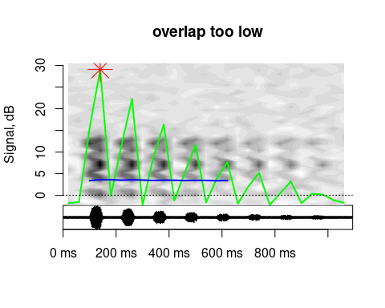

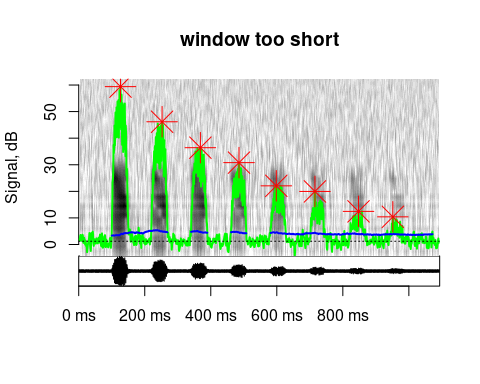

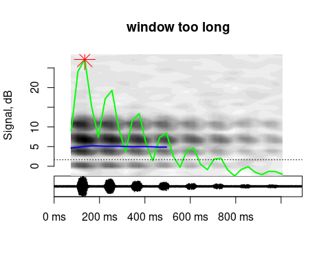

```r
a3 = segment(s2, samplingRate = 16000, plot = TRUE,
             windowLength = 150, overlap = 80, main = 'window too long')
```

- `shortestSyl` and `shortestPause` incorporate our prior knowledge by expecting the syllables and pauses between them to be at least 40 ms long (by default). Setting `shortestSyl` and `shortestPause` too low may inflate the number of discovered syllables, but burst detection should not be affected as much. If `shortestSyl` is too high, excluding shorter fragments, we won’t find any syllables, but burst detection can still succeed. The most damaging mistake is to set `shortestPause` too high, because separate syllables are then merged and the expected interburst interval becomes inflated, preventing the algorithm from recognizing closely spaced bursts (see the example below).

```r
# too long, but at least bursts are detected
a1 = segment(s2, samplingRate = 16000, plot = TRUE,
             shortestSyl = 80, main = 'shortestSyl too long')
```

```
## propNoise set to 0.394; reset manually if needed
```

```
## SNR set to 2.5; reset manually if needed
```

```
## propNoise set to 0.394; reset manually if needed
## SNR set to 2.5; reset manually if needed
```

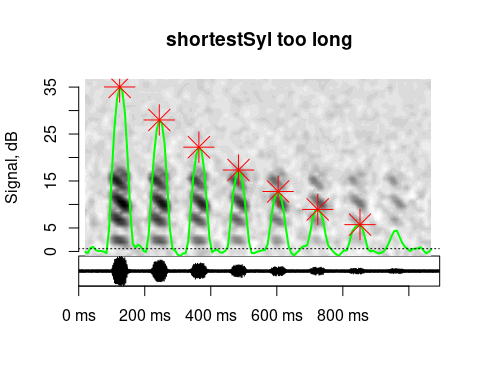

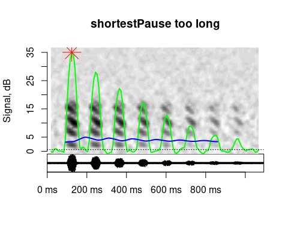

```r
# merges syllables
a2 = segment(s2, samplingRate = 16000, plot = TRUE,
             shortestPause = 80, main = 'shortestPause too long')
```

- `peakToTrough` controls how high a burst has to be compared to the local minimum. The size of the analysis window for finding local maxima and minima is controlled by `interburst`, which defaults to the median length of detected syllables + pause between them. By default the local minimum is calculated on both left and right sides of the candidate burst (`troughLocation = 'either'`). The left-right distinction is irrelevant with this artificial, perfectly symmetrical example, but setting `troughLocation = 'left'` may improve performance with real-life sounds with an assymmetric attack (sharp onset and gradual decay).

*TIP For batch processing without manual adjustments, and particularly when the focus is on describing the overall rate of acoustic events rather than on actually segmenting a recording into separate vocalizations, bursts may be more robust than syllables*